Michael Ohler Consulting  
Buchsbaumweg 6  
D-22880 Wedel  
http://www.ohlermichael.de

# Systematic and people-oriented methods for strategy, improvement and innovation

# Analytical tools to study the evolution of democracy: the "flower chart"

April 22nd 2022, by Michael Ohler

## What this study is about

For the previous two studies, I have explored data that are made avaiable by the [State of Democracy website](https://www.idea.int/data-tools/tools/global-state-democracy-indices). With 5 attributes, 3+4+4+3+2 sub-attributes, 8 sub-sub-attributes and 116 indices the dataset is both impressively rich and confusing to a novice.

In this study, I experiment with a graphical interface to explore all these data at once, either for a given country or a group of countries. For that purpose, I arrange attributes and indices in a “flower-chart”, inspired by the artwork used by the State of Democracy team.

What still needs to be fixed is to display the labels of all these attributes and indices.

# 1 All indices and attributes, averaged for the world

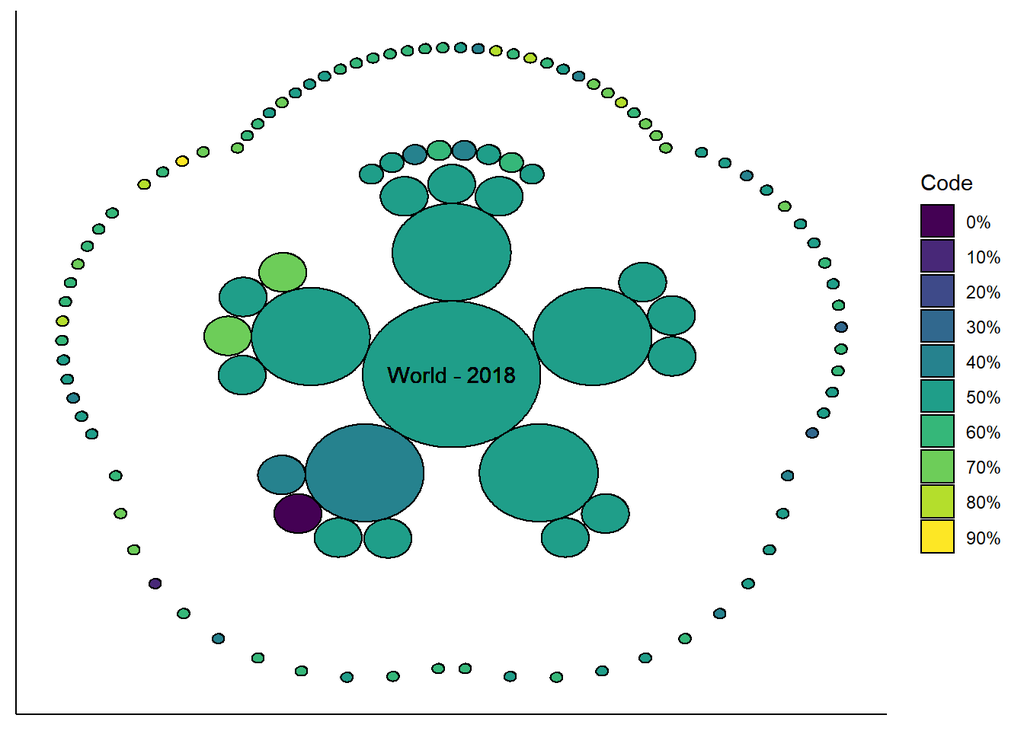

Figure 1.1: The 5 attributes, 16 sub-attributes, 8 sub-sub-attributes and 116 indices tracked by State of Democracy. The values for all countries displayed here as global average, weighted by the size of the population.

# 2 Indices for one country

In the following we study a few countries:

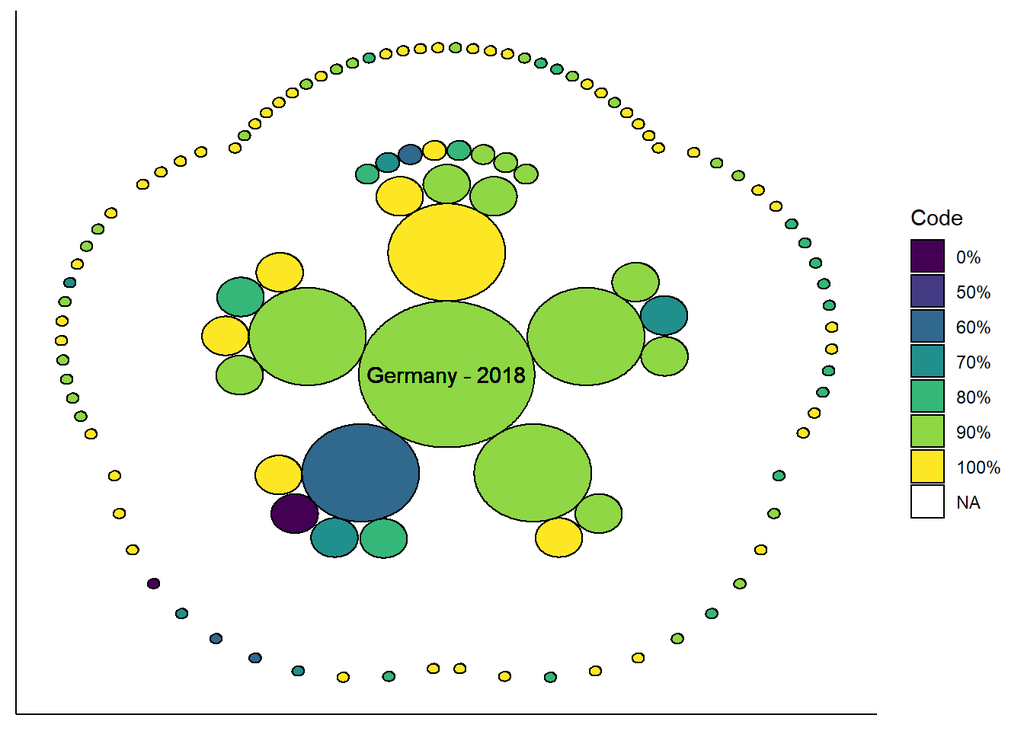

Figure 2.1: Flower-plot for one country.

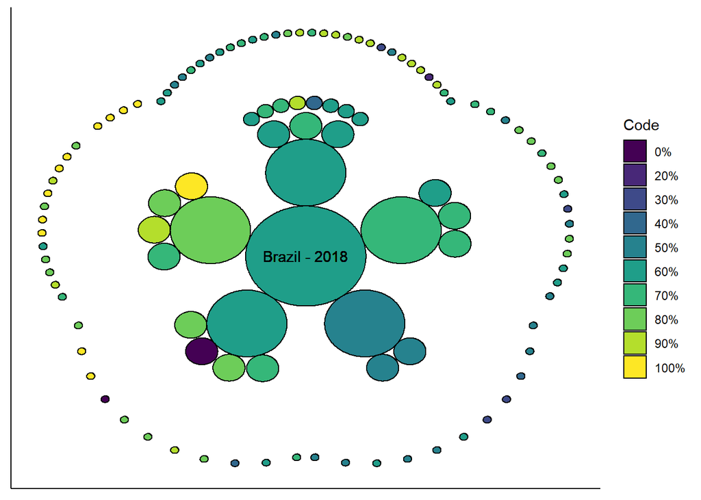

Figure 2.2: Flower-plot for one country.

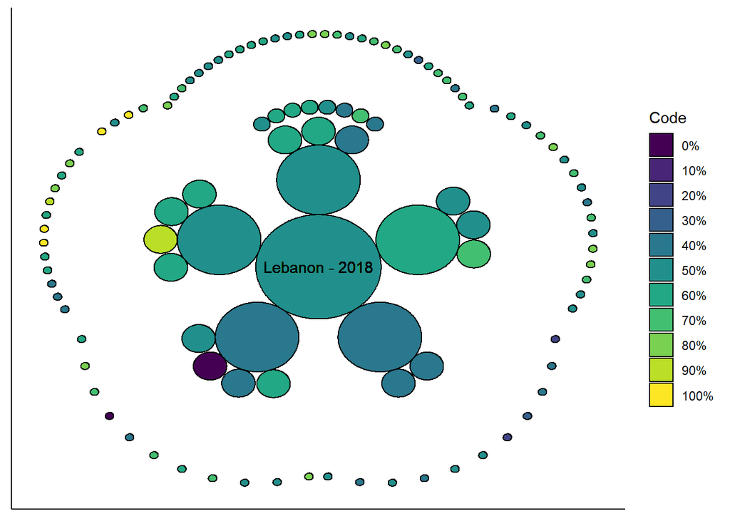

Figure 2.3: Flower-plot for one country.

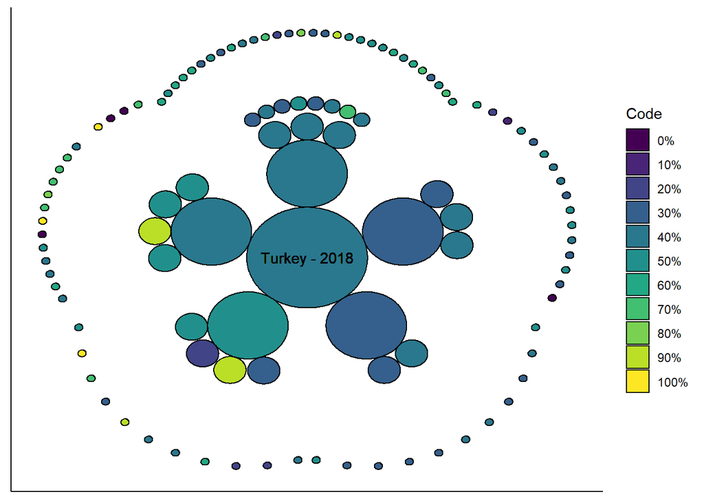

Figure 2.4: Flower-plot for one country.

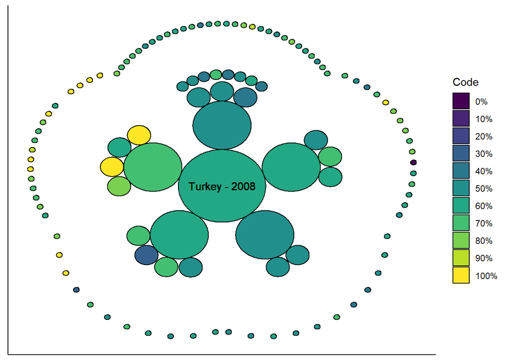

Figure 2.5: Flower-plot for one country.

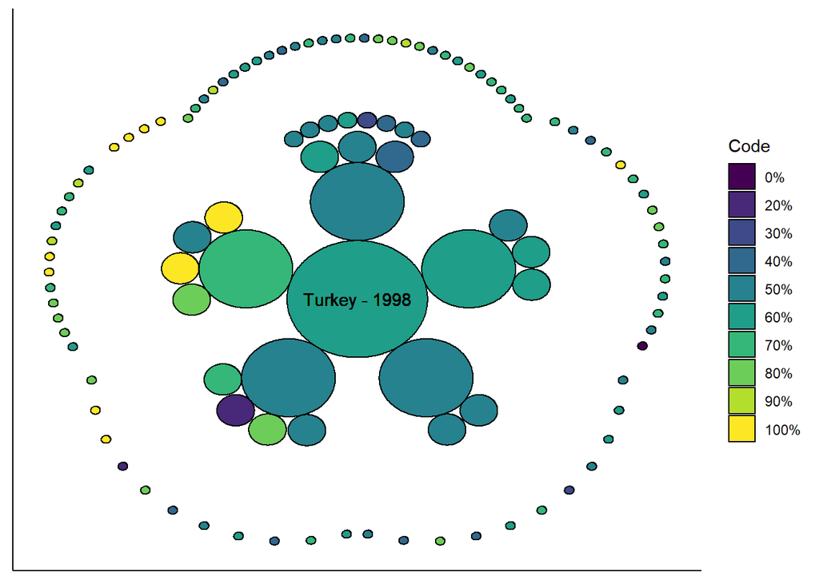

Figure 2.6: Flower-plot for one country.

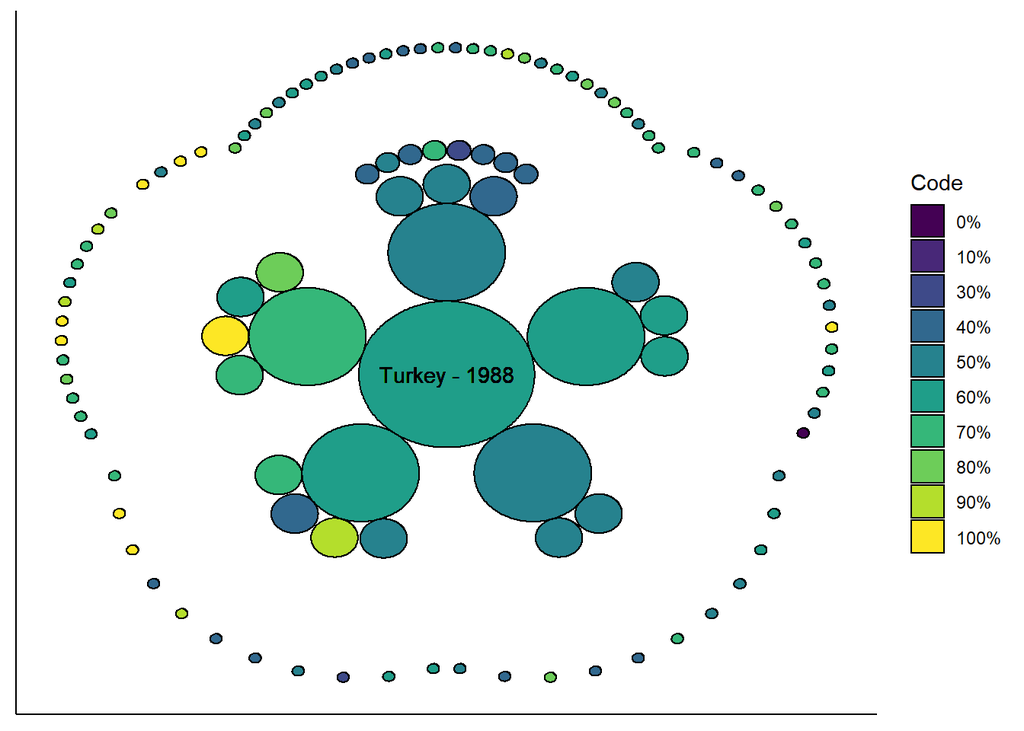

Figure 2.7: Flower-plot for one country.

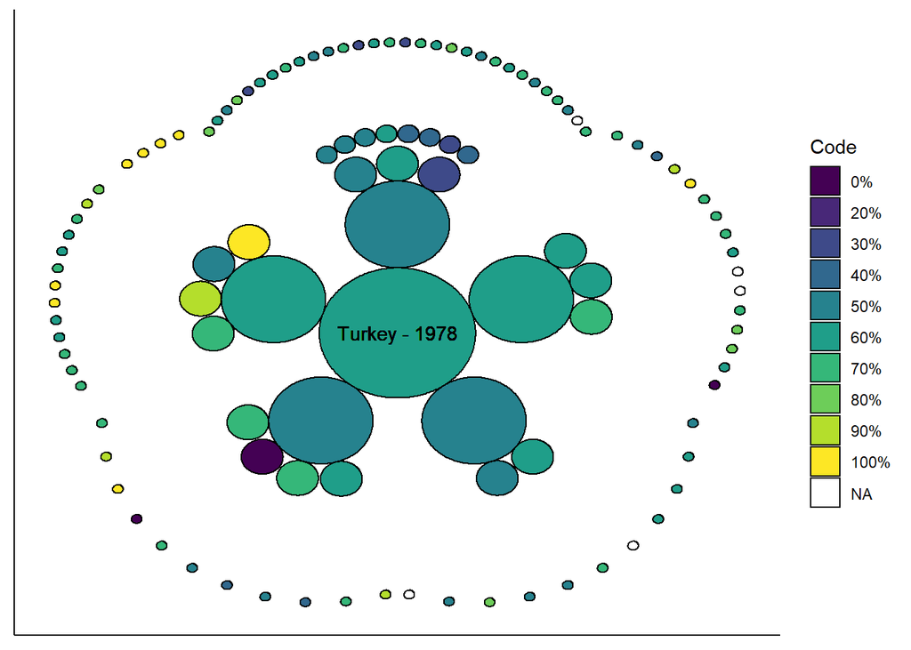

Figure 2.8: Flower-plot for one country.

# 3 Still do do

For a given year, the “flower-chart” functionality provides a good overview over all indices. What still needs to be implemented is:

- Print the names of the indices on the chart; some re-arrangement of the circles is probably needed for that
- Allow for a mouse-over-effect for an html-based report (which is easier to read than all labels printed on the graph)
- Add connection lines to the graph between indices and their “parent attribute” (only needed for the “V_…” indices).